# Hausaufgabe Session 4

•Bitte erstellen Sie ein Notebook mit weiteren Features (Alter, Geschlecht und Klasse sind als Beispiel in meinem Notebook auf GitHub)

•Was sind die Unterschiede in der Performance der Algorithmen?

Die Algorithmen funktionieren unterschiedlich gut, je nach dem welche Variablen einbezogen werden. Ich hatte das Beispiel durchlaufen lassen mit Alter, Geschlecht und Klasse und die Performance der SVM war die schlechteste, hatte aber immer noch ein AUC über 0,7. Der AUC des Naive Bayes war über 0,8 und wurde nur vom Decision Tree geschlagen. Dann habe ich den Fahrpreis hinzu genommen. Der AUC des SVM ist auf 0,827 gestiegen. Der AUC des Naive Bayes ist auf 0,783 gefallen. Decision Tree hatte immer noch den besten AUC mit 0,85.

•Finden Sie Erklärungen dafür.

Der Fahrpreis hängt mit der Klasse zusammen. Der Decision Tree wird die Klasse schon als wichtigen Faktor mit einbezogen haben, weshalb das hinzufügen des Fahrpreises keine große Veränderung gebracht hat.

Ich vermute, dass dieser Zusammenhang auch der Grund dafür ist, dass die SVM eine bessere Vorhersage treffen konnte und die zusätzliche Variable eine Trennung der Punkte im Vektorraum klarer machte.

Das schlechtere Ergebnis mit den Fahrpreis beim Naive Bayes führe ich darauf zurück, dass es beim Fahrpreis durchaus auf Distanzen ankommt.

Das Ergebnis ohne Fahrpreis, in dem die Performance des Naive Bayes besser war als der SVM, liegt vielleicht an der größe des Datensatzes.

# Libraries und Daten

```r
library(tidyverse)
library(e1071)
library(caret)
library(pROC)
```

```r
titanic <- read_delim("titanic.csv", ";",
    escape_double = FALSE, trim_ws = TRUE)
```

# Class Imbalance Check

```r
titanic %>%
  group_by(survived) %>%
  summarize(n = n())
```

| survived | n |
| --- | --- |
| 0 | 809 |
| 1 | 500 |
| NA | 1 |

# Versuch mit SVM mit 2 Variablen

```r
(titanic.df <- titanic %>%
  select(survived,pclass, sex))
```

| survived | pclass | sex |
| --- | --- | --- |
| 1 | 1 | female |
| 1 | 1 | male |
| 0 | 1 | female |
| 0 | 1 | male |
| 0 | 1 | female |
| 1 | 1 | male |
| 1 | 1 | female |
| 0 | 1 | male |
| 1 | 1 | female |
| 0 | 1 | male |

[output cut: 990 more lines]

```r
titanic.df <- na.omit(titanic.df)
titanic.df <- titanic.df %>%
  mutate(survived = as.factor(survived))
titanic.df <- titanic.df %>%
  mutate(sex = as.factor(sex))
```

```r
train_control <- trainControl(method="cv", number=10, , savePredictions = TRUE)
```

```r
set.seed(127)
inTrain <- createDataPartition(
  y = titanic.df$survived,
  p = .8,
  list = FALSE)
training <- titanic.df[ inTrain,]
testing  <- titanic.df[-inTrain,]
```

```r
model.svm <- train(survived~., data=training, trControl=train_control, method="svmLinear")

summary(model.svm)
```

```
Length  Class   Mode
     1   ksvm     S4
```

```r
pred <- predict(model.svm, testing[,-1], probability = FALSE)
```

```r
model.svm$pred
```

| pred | obs | rowIndex | C | Resample |
| --- | --- | --- | --- | --- |
| 1 | 0 | 3 | 1 | Fold01 |
| 0 | 0 | 52 | 1 | Fold01 |
| 0 | 1 | 70 | 1 | Fold01 |
| 1 | 1 | 76 | 1 | Fold01 |
| 0 | 0 | 86 | 1 | Fold01 |
| 1 | 1 | 87 | 1 | Fold01 |
| 1 | 1 | 90 | 1 | Fold01 |
| 0 | 0 | 91 | 1 | Fold01 |
| 1 | 1 | 104 | 1 | Fold01 |
| 1 | 1 | 112 | 1 | Fold01 |

[output cut: 990 more lines]

```r
(test.results <- cbind(pred, testing))
```

| pred | survived | pclass | sex |
| --- | --- | --- | --- |
| 1 | 1 | 1 | female |
| 0 | 1 | 1 | male |
| 1 | 1 | 1 | female |
| 1 | 1 | 1 | female |
| 0 | 1 | 1 | male |
| 1 | 1 | 1 | female |
| 1 | 1 | 1 | female |
| 1 | 1 | 1 | female |
| 1 | 1 | 1 | female |
| 1 | 1 | 1 | female |

[output cut: 251 more lines]

```r
test.results <- test.results %>%
  mutate(survived = as.numeric(survived)) %>%
  mutate(pred = as.numeric(pred))
```

```r
table(test.results$pred, testing$survived)
```

```
      0   1
  1 138  29
  2  23  71
```

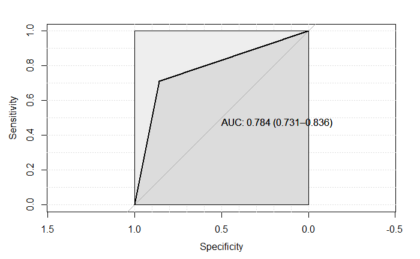

```r
pROC_obj <- roc(test.results$survived, test.results$pred,
            smoothed = TRUE,
            ci=TRUE, ci.alpha=0.9, stratified=FALSE,
            plot=TRUE, auc.polygon=TRUE, max.auc.polygon=TRUE, grid=TRUE,
            print.auc=TRUE, show.thres=TRUE)
```

# Mit mehr als zwei Features

Dataframe mit den Features Survived/Class/Sex/age/fare

```r
(titanic.df <- titanic %>%
  select(survived,pclass,sex,age,fare) %>%
   mutate(survived = as.factor(survived)))
```

| survived | pclass | sex | age | fare |
| --- | --- | --- | --- | --- |
| 1 | 1 | female | 29 | 211,3375 |
| 1 | 1 | male | 0,9167 | 151,5500 |
| 0 | 1 | female | 2 | 151,5500 |
| 0 | 1 | male | 30 | 151,5500 |
| 0 | 1 | female | 25 | 151,5500 |
| 1 | 1 | male | 48 | 26,5500 |
| 1 | 1 | female | 63 | 77,9583 |
| 0 | 1 | male | 39 | 0,0000 |
| 1 | 1 | female | 53 | 51,4792 |
| 0 | 1 | male | 71 | 49,5042 |

[output cut: 990 more lines]

```r
titanic.df <- titanic.df %>%
  mutate(age = as.numeric(str_replace(age,",",".")))
titanic.df <- titanic.df %>%
  mutate(fare = as.numeric(str_replace(fare,",","")))
```

```r
titanic.df <- na.omit(titanic.df)
```

Geschlecht zum Faktor machen

```r
titanic.df <- titanic.df %>%
  mutate(sex = ifelse(sex == "female", 1, 0)) %>%
  mutate(sex = as.factor(sex))
```

SVM

```r
set.seed(393)
inTrain <- createDataPartition(
  y = titanic.df$survived,
  p = .8,
  list = FALSE)
training <- titanic.df[ inTrain,]
testing  <- titanic.df[-inTrain,]
```

```r
model.svm <- svm(formula = survived ~ ., data = training, probability=TRUE)
summary(model.svm)
```

```
Call:
svm(formula = survived ~ ., data = training, probability = TRUE)


Parameters:
   SVM-Type:  C-classification
 SVM-Kernel:  radial
       cost:  1

Number of Support Vectors:  415

 ( 206 209 )


Number of Classes:  2

Levels:
 0 1
```

```r
pred <- predict(model.svm, testing[,-1], probability = TRUE)
```

```r
(test.results <- cbind(pred, testing))
```

|  | pred | survived | pclass | sex | age | fare |
| --- | --- | --- | --- | --- | --- | --- |
| 1 | 1 | 1 | 1 | 0 | 0.9167 | 1515500 |
| 2 | 1 | 1 | 1 | 1 | 18.0000 | 2275250 |
| 3 | 1 | 1 | 1 | 1 | 24.0000 | 693000 |
| 4 | 0 | 0 | 1 | 0 | 24.0000 | 2475208 |
| 5 | 0 | 0 | 1 | 0 | 25.0000 | 260000 |
| 6 | 0 | 0 | 1 | 0 | 42.0000 | 265500 |
| 7 | 1 | 1 | 1 | 1 | 59.0000 | 514792 |
| 8 | 1 | 1 | 1 | 1 | 60.0000 | 762917 |
| 9 | 0 | 0 | 1 | 0 | 45.0000 | 265500 |
| 10 | 1 | 1 | 1 | 1 | 58.0000 | 5123292 |

[output cut: 198 more lines]

```r
head(attr(pred, "probabilities"))
```

```
          1          0
1 0.8400589 0.15994110
2 0.8493023 0.15069766
3 0.9249755 0.07502453
4 0.4222879 0.57771208
5 0.3676329 0.63236707
6 0.2282223 0.77177770
```

```r
confusionMatrix(pred,testing$survived)
```

```
Confusion Matrix and Statistics

          Reference
Prediction   0   1
         0 118  26
         1   5  59

               Accuracy : 0.851
                 95% CI : (0.7952, 0.8964)
    No Information Rate : 0.5913
    P-Value [Acc > NIR] : 4.122e-16

                  Kappa : 0.6794

 Mcnemar's Test P-Value : 0.000328

            Sensitivity : 0.9593
            Specificity : 0.6941
         Pos Pred Value : 0.8194
         Neg Pred Value : 0.9219
             Prevalence : 0.5913
         Detection Rate : 0.5673
   Detection Prevalence : 0.6923
      Balanced Accuracy : 0.8267

       'Positive' Class : 0
```

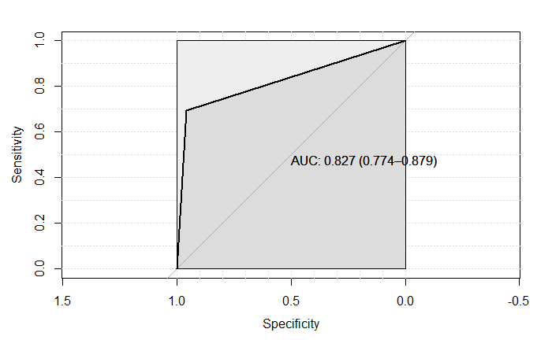

```r
library(pROC)
pROC_obj <- roc(as.numeric(test.results$survived), as.numeric(test.results$pred),
            smoothed = TRUE,
            ci=TRUE, ci.alpha=0.9, stratified=FALSE,
            plot=TRUE, auc.polygon=TRUE, max.auc.polygon=TRUE, grid=TRUE,
            print.auc=TRUE, show.thres=TRUE)
```

## Das Modell speichern

```r
saveRDS(model.svm, "./titanic.svm.rds")
```

# Naive Bayes

```r
my_training <- training %>%
  mutate(survived = as.factor(survived))%>%
  mutate(sex = as.factor(sex))%>%
  mutate(pclass = as.factor(pclass)) %>%
mutate(age = as.factor(ifelse(age < 14, "child", "adult")))
model <- naiveBayes(survived ~ ., data = my_training)
model
```

```
Naive Bayes Classifier for Discrete Predictors

Call:
naiveBayes.default(x = X, y = Y, laplace = laplace)

A-priori probabilities:
Y
        0         1
0.5913978 0.4086022

Conditional probabilities:
   pclass
Y           1         2         3
  0 0.1474747 0.2363636 0.6161616
  1 0.4444444 0.2368421 0.3187135

   sex
Y           0         1
  0 0.8323232 0.1676768
  1 0.3304094 0.6695906

   age
Y        adult      child
  0 0.92323232 0.07676768
  1 0.88011696 0.11988304

   fare
Y       [,1]     [,2]
  0 249594.6 354468.4
  1 556434.1 739710.4
```

```r
my_testing <- testing %>%
  mutate(sex = as.factor(sex)) %>%
  mutate(pclass = as.factor(pclass))%>%
  mutate(age = as.factor(ifelse(age < 7, "child", "adult")))
pred <- predict(model, my_testing)
table(pred, my_testing$survived)
```

```
pred   0   1
   0 113  30
   1  10  55
```

```r
(test.results <- cbind(pred, my_testing))
```

| pred | survived | pclass | sex | age | fare |
| --- | --- | --- | --- | --- | --- |
| 1 | 1 | 1 | 0 | child | 1515500 |
| 1 | 1 | 1 | 1 | adult | 2275250 |
| 1 | 1 | 1 | 1 | adult | 693000 |
| 1 | 0 | 1 | 0 | adult | 2475208 |
| 0 | 0 | 1 | 0 | adult | 260000 |
| 0 | 0 | 1 | 0 | adult | 265500 |
| 1 | 1 | 1 | 1 | adult | 514792 |
| 1 | 1 | 1 | 1 | adult | 762917 |
| 0 | 0 | 1 | 0 | adult | 265500 |
| 1 | 1 | 1 | 1 | adult | 5123292 |

[output cut: 198 more lines]

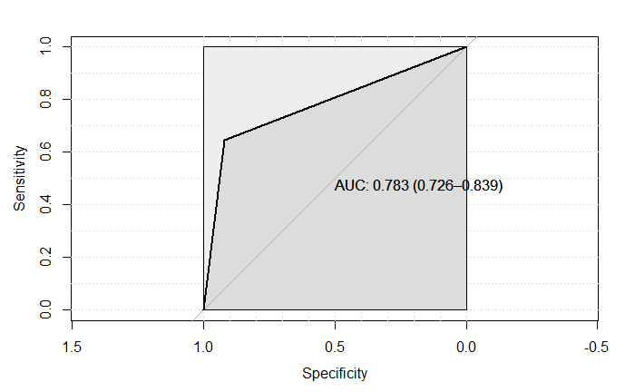

```r
test.results <- test.results %>%
  mutate(pred = as.numeric(pred))
pROC_obj <- roc(as.numeric(as.factor(test.results$survived)), test.results$pred,
            smoothed = TRUE,
            ci=TRUE, ci.alpha=0.9, stratified=FALSE,
            plot=TRUE, auc.polygon=TRUE, max.auc.polygon=TRUE, grid=TRUE,
            print.auc=TRUE, show.thres=TRUE)
```

# Decision Tree

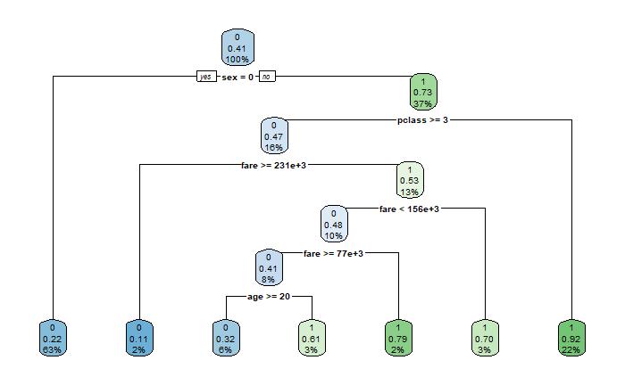

```r
library(rpart)
library(rpart.plot)
tree<- rpart(survived~., data = training, method = 'class')
rpart.plot(tree)
```

```r
dt_results <- predict(tree, testing[,-1], type = 'prob')
head(model.results.dt <- cbind(testing,dt_results),500)
```

|  | survived | pclass | sex | age | fare | 0 | 1 |
| --- | --- | --- | --- | --- | --- | --- | --- |
| 1 | 1 | 1 | 0 | 0.9167 | 1515500 | 0.78476190 | 0.2152381 |
| 2 | 1 | 1 | 1 | 18.0000 | 2275250 | 0.07692308 | 0.9230769 |
| 3 | 1 | 1 | 1 | 24.0000 | 693000 | 0.07692308 | 0.9230769 |
| 4 | 0 | 1 | 0 | 24.0000 | 2475208 | 0.78476190 | 0.2152381 |
| 5 | 0 | 1 | 0 | 25.0000 | 260000 | 0.78476190 | 0.2152381 |
| 6 | 0 | 1 | 0 | 42.0000 | 265500 | 0.78476190 | 0.2152381 |
| 7 | 1 | 1 | 1 | 59.0000 | 514792 | 0.07692308 | 0.9230769 |
| 8 | 1 | 1 | 1 | 60.0000 | 762917 | 0.07692308 | 0.9230769 |
| 9 | 0 | 1 | 0 | 45.0000 | 265500 | 0.78476190 | 0.2152381 |
| 10 | 1 | 1 | 1 | 58.0000 | 5123292 | 0.07692308 | 0.9230769 |

[output cut: 198 more lines]

```r
test.results2 <- test.results %>%
  mutate(pred = ifelse(pred>=0.5,1,0))
table(test.results2$pred, testing$survived)
```

```
      0   1
  1 123  85
```

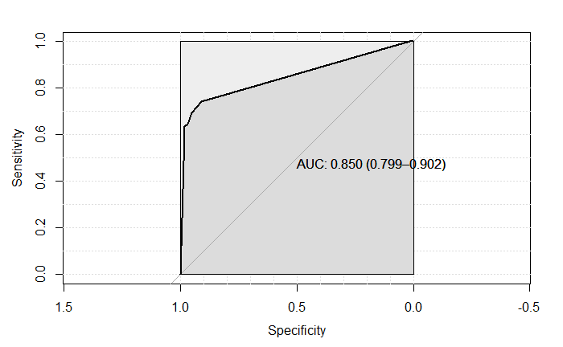

```r
pROC_obj <- roc(model.results.dt$survived,model.results.dt$`1`,
            smoothed = TRUE,
            # arguments for ci
            ci=TRUE, ci.alpha=0.9, stratified=FALSE,
            # arguments for plot
            plot=TRUE, auc.polygon=TRUE, max.auc.polygon=TRUE, grid=TRUE,
            print.auc=TRUE, show.thres=TRUE)
```